# Homework 10

**Due: 2022-5-12, 10:30am**

We will use the [Colon Cancer Dataset](https://r-data.pmagunia.com/dataset/r-dataset-package-survival-colon). These are data from one of the first successful trials of adjuvant chemotherapy for colon cancer. Levamisole is a low-toxicity compound previously used to treat worm infestations in animals; 5-FU is a moderately toxic (as these things go) chemotherapy agent.

You can check the data information through [Colon Cancer Dataset](https://r-data.pmagunia.com/dataset/r-dataset-package-survival-colon) and load the colon data set in R by issuing the following command.

```r
library(survival)
library(dplyr)
dim(colon)
```

```
## [1] 1858   16
```

```r
head(colon)
```

```
##   id study      rx sex age obstruct perfor adhere nodes status differ extent
## 1  1     1 Lev+5FU   1  43        0      0      0     5      1      2      3
## 2  1     1 Lev+5FU   1  43        0      0      0     5      1      2      3
## 3  2     1 Lev+5FU   1  63        0      0      0     1      0      2      3
## 4  2     1 Lev+5FU   1  63        0      0      0     1      0      2      3
## 5  3     1     Obs   0  71        0      0      1     7      1      2      2
## 6  3     1     Obs   0  71        0      0      1     7      1      2      2
##   surg node4 time etype
## 1    0     1 1521     2
## 2    0     1  968     1
## 3    0     0 3087     2
## 4    0     0 3087     1
## 5    0     1  963     2
## 6    0     1  542     1
```

There are two records per person, one for recurrence and one for death (etype: 1=recurrence,2=death). Here we will just focus on `etype==2` using the following command.

```r
colondeath <- subset(colon, etype==2)
```

1. (20%) Using the `ggsurvplot()` from `survminer` package, plot Kaplan-Meier curves for males versus females with confidence intervals and showing the p-value. Is there a significant difference between males and females?

```r
library(survminer)
table(colondeath$sex) # 1=Male
```

```
##
##   0   1
## 445 484
```

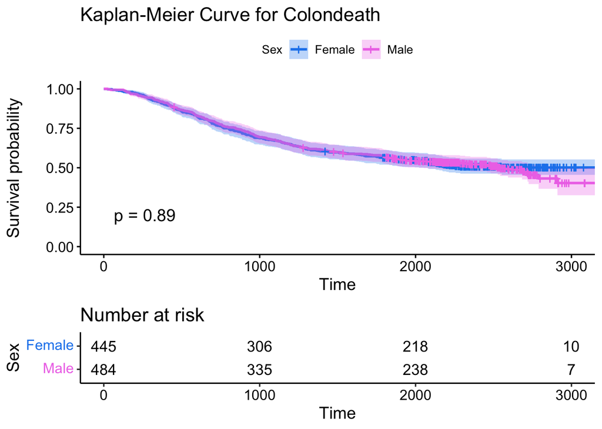

```r
sfit <- survfit(Surv(time, status)~sex, data=colondeath)
# summary(sfit)
ggsurvplot(
  sfit,
  conf.int = TRUE,
  pval = TRUE,
  risk.table = TRUE,
  legend.labs = c("Female","Male"),
  legend.title = "Sex",
  palette = c("dodgerblue2", "orchid2"),
  title = "Kaplan-Meier Curve for Colondeath",
  risk.table.height = .3
)
```

No, there is no significant difference between males and females.

2. (20%) Create Kaplan-Meier plot stratifying by:
1. The extent of differentiation (well, moderate, poor), showing the p-value and confidence bands.
2. Whether or not there was detectable cancer in >=4 lymph nodes, showing the p-value and confidence bands.

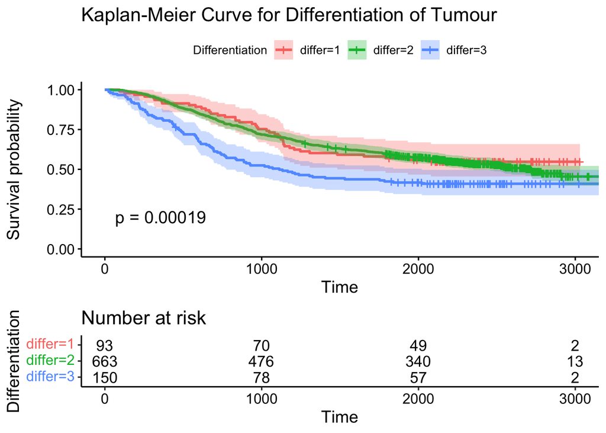

```r
sfit.differ <- survfit(Surv(time, status)~differ, data=colondeath)
ggsurvplot(
  sfit.differ,
  conf.int = TRUE,
  pval = TRUE,
  risk.table = TRUE,
  legend.title = "Differentiation",
  title = "Kaplan-Meier Curve for Differentiation of Tumour",
  risk.table.height = .3
)
```

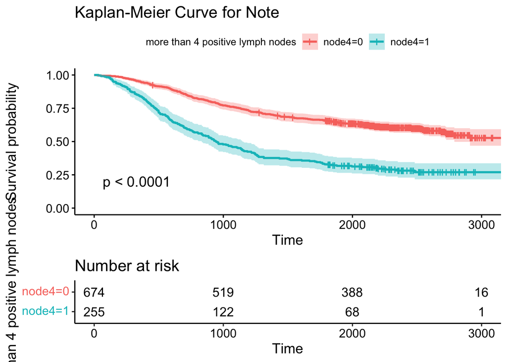

```r
sfit.node4 <- survfit(Surv(time, status)~node4, data=colondeath)
ggsurvplot(
  sfit.node4,
  conf.int = TRUE,
  pval = TRUE,
  risk.table = TRUE,
  legend.title = "more than 4 positive lymph nodes",
  title = "Kaplan-Meier Curve for Note",
  risk.table.height = .3
)
```

3. (20%) Run a Cox proportional hazards regression model against Treatment (`rx`) variable. How do you interpret the result? Which treatment seems to be significantly different from the control (Observation)?

```r
table(colondeath$rx)
```

```
##
##     Obs     Lev Lev+5FU
##     315     310     304
```

```r
fit <- coxph(Surv(time, status)~rx, data=colondeath)
summary(fit)
```

```
## Call:
## coxph(formula = Surv(time, status) ~ rx, data = colondeath)
##
##   n= 929, number of events= 452
##
##               coef exp(coef) se(coef)      z Pr(>|z|)
## rxLev     -0.02664   0.97371  0.11030 -0.241  0.80917
## rxLev+5FU -0.37171   0.68955  0.11875 -3.130  0.00175 **
## ---
## Signif. codes:  0 '***' 0.001 '**' 0.01 '*' 0.05 '.' 0.1 ' ' 1
##
##           exp(coef) exp(-coef) lower .95 upper .95
## rxLev        0.9737      1.027    0.7844    1.2087
## rxLev+5FU    0.6896      1.450    0.5464    0.8703
##
## Concordance= 0.536  (se = 0.013 )
## Likelihood ratio test= 12.15  on 2 df,   p=0.002
## Wald test            = 11.56  on 2 df,   p=0.003
## Score (logrank) test = 11.68  on 2 df,   p=0.003
```

Treatment is significant associated with time to death. rxLev+5FU is significantly different from the control (Observation). Using rxLev+5FU reduces the hazard by a factor of 0.68955.

4. (20%) Show the results in Question 3 using a Kaplan-Meier plot, with confidence intervals and the p-value.

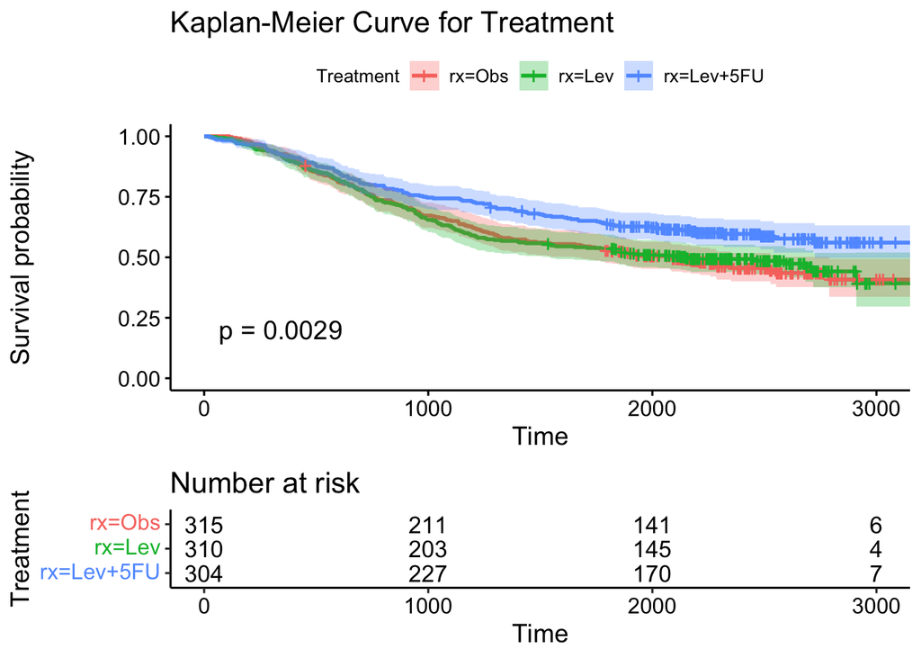

```r
sfit.rx <- survfit(Surv(time, status)~rx, data=colondeath)
ggsurvplot(
  sfit.rx,
  conf.int = TRUE,
  pval = TRUE,
  risk.table = TRUE,
  legend.title = "Treatment",
  title = "Kaplan-Meier Curve for Treatment",
  risk.table.height = .3
)
```

5. (20%) Fit another Cox regression model accounting for treatment, age, sex, number of nodes with detectable cancer, and differentiation of tumour. Interpret the result.

```r
fit.all <- coxph(Surv(time,status)~rx+age+sex+nodes+differ, data=colondeath)
fit.all
```

```
## Call:
## coxph(formula = Surv(time, status) ~ rx + age + sex + nodes +
##     differ, data = colondeath)
##
##                coef exp(coef)  se(coef)      z       p
## rxLev     -0.085071  0.918447  0.113598 -0.749 0.45393
## rxLev+5FU -0.393673  0.674575  0.121359 -3.244 0.00118
## age        0.005996  1.006014  0.004096  1.464 0.14323
## sex       -0.044542  0.956436  0.096959 -0.459 0.64596
## nodes      0.088530  1.092567  0.009203  9.619 < 2e-16
## differ     0.189589  1.208752  0.099643  1.903 0.05708
##
## Likelihood ratio test=87.27  on 6 df, p=< 2.2e-16
## n= 888, number of events= 430
##    (41 observations deleted due to missingness)
```

Accounting for treatment, age, sex, number of nodes with detectable cancer, and differentiation of tumour. Interpret the result, cox regression shows that treatment and number of nodes with detectable cancer is significantly assocaited with time to death.